# Laboratorio 2

**Rodrigo Chang** *Carné: 19000625*

Cargamos las librerías para obtener los datos y manipularlos.

```r
library(MASS)
library(dplyr)
```

# Replanteamos el ejercicio hecho en clase

Cargamos los datos y ajustamos los nombres de las columnas para poder crear una fórmula modificable de “input”

```r
# Carga de datos
data <- Boston %>%
  dplyr::select(lstat,medv)
names(data)[1] <- "input"
names(data)[2] <- "output"
str(data)
```

```
'data.frame':   506 obs. of  2 variables:
 $ input : num  4.98 9.14 4.03 2.94 5.33 ...
 $ output: num  24 21.6 34.7 33.4 36.2 28.7 22.9 27.1 16.5 18.9 ...
```

## Algunas funciones de ayuda

Creamos una función para obtener una muestra de bootstrap del dataset:

```r
# Función para obtener un boot sample
get_boot_sample <- function(x, dataset, size) {
  return(sample_n(dataset, size = size, replace = TRUE))
}
```

Esta función se utiliza para ajustar un modelo de polinomial de output ~ f(input).

```r
# Función para ajustar modelo de grado 'degree'
fit_lm <- function(dataset, degree = 2) {
  if (degree == 0) {
    fit <- lm("output ~ 1", data = dataset)
  } else {
    formula <- paste0("I(","input^", 1:degree, ")", collapse = '+')
    formula <- paste0("output ~ ", formula)
    fit <- lm(formula, data = dataset)
  }
  return(fit)
}
```

Esta función nos servirá para obtener los valores ajustados del modelo en el rango de la variable *input*

```r
# Esta función genera los valores de pronóstico para las gráficas
model_fitted_plotdata <- function(fit){
  xaxis <- seq(min(data$input), max(data$input), by=0.01)
  yaxis <- predict(fit, tibble(input = xaxis))
  return(tibble(input = xaxis, output = yaxis))
}
model_fitted_values <- function(fit, dataset) {
  xaxis <- dataset$input
  yaxis <- predict(fit, tibble(input = xaxis))
  return(tibble(input = xaxis, output = dataset$output, f = yaxis))
}
```

Ahora vamos a graficar todas las funciones de hipótesis con muestras de bootstrap:

## Gráficas de todas las funciones de hipótesis

```r
# Definiciones para el ejercicio de bootstrap
nboots <- 100
bootsize <- nrow(data)
# Obtenemos las muestras de bootstrap en una lista
boot_samples <- lapply(1 : nboots, get_boot_sample, dataset = data, size = bootsize)
# Obtenemos una lista de modelos ajustados con la muestra y obtenemos los valores ajustados
all.models <- lapply(boot_samples, fit_lm, degree = 10)
all.model.predictions <- lapply(all.models, model_fitted_plotdata)
```

Vamos a graficar el valor promedio de las funciones de hipótesis

```r
# Obtenemos todas las funciones de hipótesis en una misma estructura
all.hypothesis <- bind_rows(all.model.predictions, .id = "boot")
# Obtenemos la media con dplyr
mean_pred <- all.hypothesis %>%
  group_by(input) %>%
  summarise(mean_fn = mean(output))
# Graficamos las hipótesis en gris y los valores promedio en rojo
plot(data, pch=20, cex=0.25)
for(i in 1:nboots) {
  points(all.model.predictions[[i]], col='gray', type='l')
}
```

[figure not shown]

```r
points(mean_pred, type = 'l', col='red')
```

# Cómputo del sesgo y la varianza

Ahora vamos a obtener los valores ajustados de todos los modelos para el dataset original.

```r
datatest <- data
for (i in 1:100) {
  modelo_str <- paste("f", i, sep = "")
  datatest[[modelo_str]] <- predict(all.models[[i]], tibble(input = datatest$input))
}
head(datatest)
```

|  | input | output | f1 | f2 | f3 | f4 | f5 | f6 | f7 | f8 | f9 | f10 | f11 | f12 | f13 | f14 | f15 | f16 | f17 | f18 | f19 | f20 | f21 | f22 | f23 | f24 | f25 | f26 | f27 | … |
| --- | --- | --- | --- | --- | --- | --- | --- | --- | --- | --- | --- | --- | --- | --- | --- | --- | --- | --- | --- | --- | --- | --- | --- | --- | --- | --- | --- | --- | --- | --- |
| 1 | 4.98 | 24.0 | 31.30224 | 31.60634 | 30.84321 | 30.61292 | 31.52725 | 32.36353 | 30.85339 | 30.84829 | 31.98718 | 31.19176 | 33.24747 | 32.15294 | 31.68165 | 31.27213 | 30.69813 | 32.33775 | 30.41180 | 31.32086 | 31.70750 | 30.19204 | 30.64718 | 32.56600 | 31.85443 | 31.61193 | 30.76537 | 31.91472 | 32.34852 | … |
| 2 | 9.14 | 21.6 | 24.97185 | 23.93773 | 24.20645 | 23.53714 | 23.64920 | 24.15371 | 25.97280 | 24.28787 | 23.89894 | 24.12833 | 23.96384 | 23.49881 | 23.97046 | 24.73842 | 24.03932 | 24.68015 | 23.98836 | 24.10420 | 24.29127 | 24.13586 | 24.86526 | 23.37515 | 23.56542 | 24.04946 | 24.16947 | 23.80483 | 23.56409 | … |
| 3 | 4.03 | 34.7 | 36.72109 | 36.19214 | 35.50067 | 35.76345 | 37.67430 | 37.53355 | 36.56978 | 34.09579 | 36.94999 | 36.24231 | 37.72288 | 37.65311 | 36.10706 | 36.12928 | 35.72756 | 37.54376 | 36.56499 | 36.85007 | 36.98048 | 35.66981 | 36.23478 | 38.98779 | 36.44785 | 38.38768 | 34.76286 | 36.70949 | 37.11700 | … |
| 4 | 2.94 | 33.4 | 43.51817 | 43.15826 | 42.78395 | 42.78540 | 44.19201 | 43.49353 | 43.79791 | 40.49602 | 44.24783 | 43.80670 | 41.80510 | 43.26160 | 41.79002 | 43.15931 | 43.47177 | 43.74039 | 44.66895 | 45.63657 | 44.47937 | 43.03424 | 43.18163 | 47.05952 | 42.11427 | 44.97422 | 42.19049 | 43.13447 | 42.41342 | … |
| 5 | 5.33 | 36.2 | 29.82457 | 30.31661 | 29.62540 | 29.15993 | 29.70998 | 30.79595 | 29.34966 | 29.98366 | 30.57994 | 29.79430 | 31.77140 | 30.51123 | 30.35299 | 29.98149 | 29.33681 | 30.83972 | 28.70323 | 29.83243 | 30.26740 | 28.70522 | 29.14427 | 30.66596 | 30.43954 | 29.65533 | 29.70558 | 30.49810 | 30.84860 | … |
| 6 | 5.21 | 28.7 | 30.29743 | 30.73598 | 30.01488 | 29.63019 | 30.29999 | 31.30931 | 29.82578 | 30.26498 | 31.03774 | 30.24608 | 32.26165 | 31.04574 | 30.78874 | 30.39443 | 29.77496 | 31.32501 | 29.25262 | 30.31145 | 30.73096 | 29.18140 | 29.62322 | 31.28600 | 30.90560 | 30.28550 | 30.04840 | 30.96162 | 31.34366 | … |

Vamos a computar el valor promedio $\bar{\hat{f}}$ de las funciones de hipótesis para cada $x_j$:

```r
f_hat_mean <- datatest %>%
  dplyr::select(starts_with("f")) %>%
  rowSums / 100
```

Ahora vamos a computar la varianza del modelo en cada $x_j$

```r
varX <- (1/(100-1)) * rowSums((datatest %>% dplyr::select(starts_with("f")) - f_hat_mean)^2)
varianza <- mean(varX)
varianza
```

```
[1] 52.91963
```

Ahora vamos a computar el sesgo (al cuadrado) del modelo en cada $x_j$

```r
sesgoX <- (datatest$output - f_hat_mean)^2
sesgo <- mean(sesgoX)
sesgo
```

```
[1] 26.65833
```

# Ejercicio de implementación

Vamos a crear una función más general para obtener la varianza del modelo en función del grado del polinomio.

```r
# Función para la varianza
sesgo.varianza.fn <- function(grado, df, B, n) {

  print(sprintf("Generando modelo de complejidad %d", grado))

  # Obtenemos las muestras de bootstrap en una lista
  boot_samples <- lapply(1 : B, get_boot_sample, dataset = df, size = n)

  # Obtenemos una lista de modelos ajustados con la muestra y obtenemos los valores ajustados
  all.models <- lapply(boot_samples, fit_lm, degree = grado)

  # Generamos los valores ajustados de todos los modelos
  datatest <- df
  for (i in 1:B) {
    modelo_str <- paste("f", i, sep = "")
    datatest[[modelo_str]] <- predict(all.models[[i]], tibble(input = datatest$input))
  }
  # Computamos los valores ajustados promedio
  f_hat_mean <- datatest %>%
  dplyr::select(starts_with("f")) %>%
  rowSums / 100

  # Obtenemos la varianza
  varX <- (1/(B-1)) * rowSums((datatest %>% dplyr::select(starts_with("f")) - f_hat_mean)^2)
  varianza <- mean(varX)

  # Obtener el sesgo
  sesgoX <- (datatest$output - f_hat_mean)^2
  sesgo <- mean(sesgoX)

  return(c("Sesgo" = sesgo, "Varianza" = varianza))
}
```

Ahora, vamos a generar modelos de diferente complejidad para evaluar su sesgo y precisión:

```r
cmplx = 12
modl.var <- lapply(c(0:cmplx), sesgo.varianza.fn, df = data, B = 100, n = nrow(data))
```

```
[1] "Generando modelo de complejidad 0"
[1] "Generando modelo de complejidad 1"
[1] "Generando modelo de complejidad 2"
[1] "Generando modelo de complejidad 3"
[1] "Generando modelo de complejidad 4"
[1] "Generando modelo de complejidad 5"
[1] "Generando modelo de complejidad 6"
[1] "Generando modelo de complejidad 7"
[1] "Generando modelo de complejidad 8"
[1] "Generando modelo de complejidad 9"
[1] "Generando modelo de complejidad 10"
[1] "Generando modelo de complejidad 11"
[1] "Generando modelo de complejidad 12"
```

Organizamos nuestros datos de sesgo y varianza en función del grado del polinomio:

```r
dataComplex <- as.data.frame(do.call(rbind, modl.var))
dataComplex[["GradoPolinomio"]] = 0:cmplx
dataComplex
```

| Sesgo | Varianza | GradoPolinomio |
| --- | --- | --- |
| 84.42123 | 0.1903184 | 0 |
| 38.48303 | 0.2242457 | 1 |
| 30.33096 | 0.2124903 | 2 |
| 28.88821 | 0.2705731 | 3 |
| 27.61733 | 0.4252330 | 4 |
| 26.87931 | 0.4004894 | 5 |
| 26.80283 | 0.5782779 | 6 |
| 26.92703 | 1.6298182 | 7 |
| 26.71061 | 2.8741042 | 8 |
| 29.12867 | 27.4294517 | 9 |

[output cut: 3 more lines]

## Graficamos el sesgo y la varianza

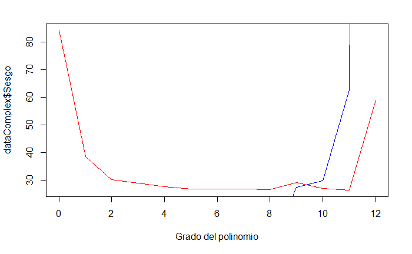

```r
plot(x=dataComplex$GradoPolinomio, y=dataComplex$Sesgo, type = "l", col = "red",
     xlab = "Grado del polinomio")
lines(x=dataComplex$GradoPolinomio, y=dataComplex$Varianza, type = "l", col = "blue")
```